# mini-project-2

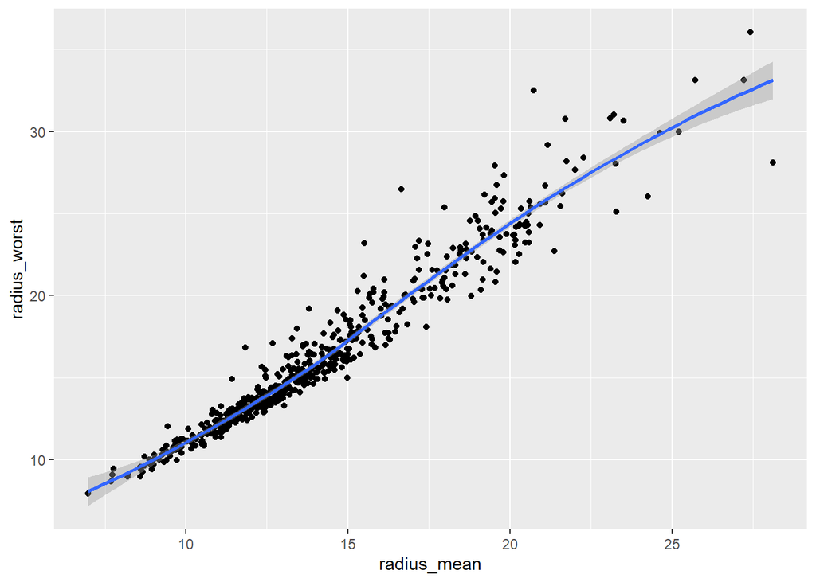

```r
ggplot(data = cancer, mapping = aes(x = radius_mean, y = radius_worst)) +
  geom_point() +
  geom_smooth()
```

2. Are there variables that have relationship with diagnosis?

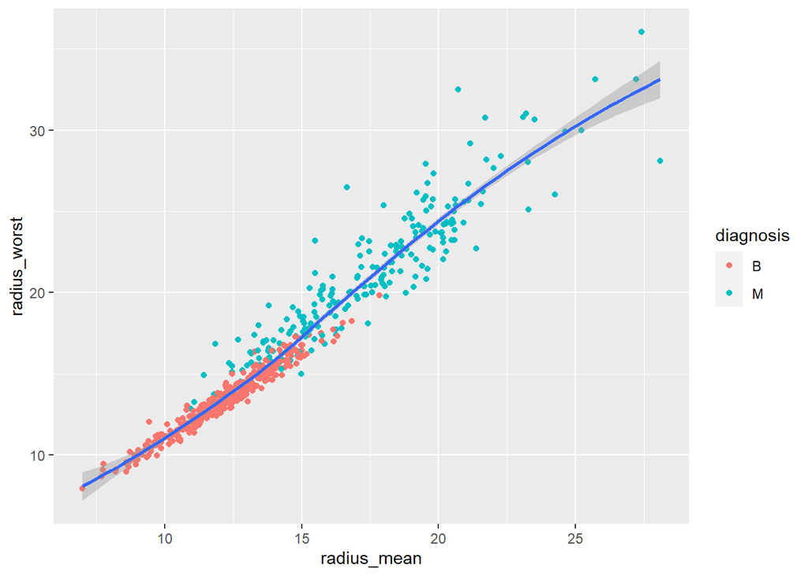

```r
ggplot(data = cancer, mapping = aes(x = radius_mean, y = radius_worst)) +
  geom_point(mapping = aes(color = diagnosis)) +
  geom_smooth()
```

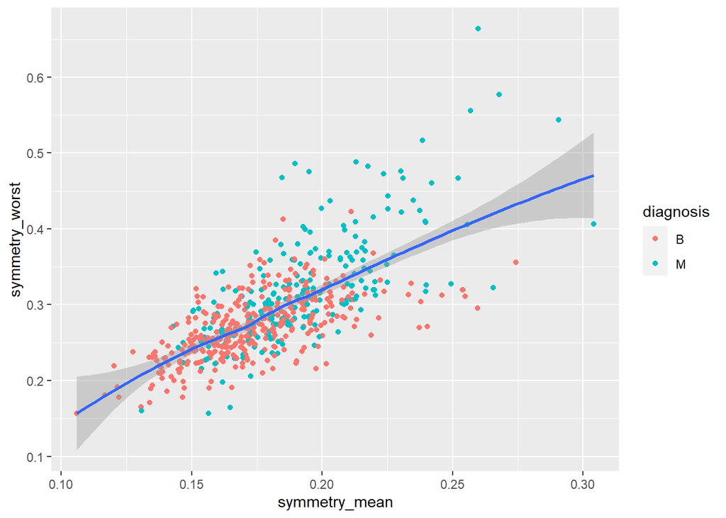

```r
ggplot(data = cancer, mapping = aes(x = symmetry_mean, y = symmetry_worst)) +
  geom_point(mapping = aes(color = diagnosis)) +
  geom_smooth()
```

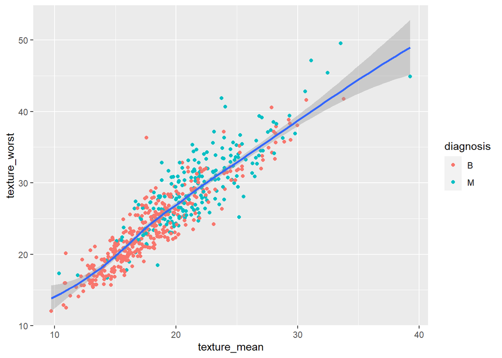

```r
ggplot(data = cancer, mapping = aes(x = texture_mean, y = texture_worst)) +
  geom_point(mapping = aes(color = diagnosis)) +
  geom_smooth()
```

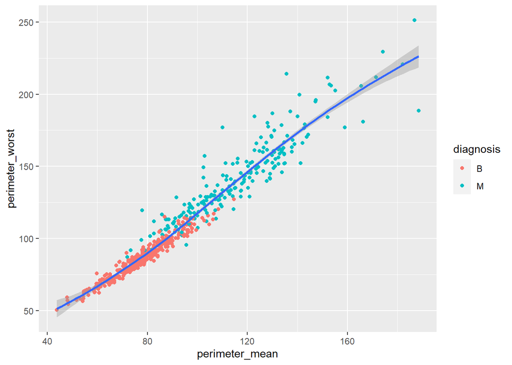

```r
ggplot(data = cancer, mapping = aes(x = perimeter_mean, y = perimeter_worst)) +
  geom_point(mapping = aes(color = diagnosis)) +
  geom_smooth()
```

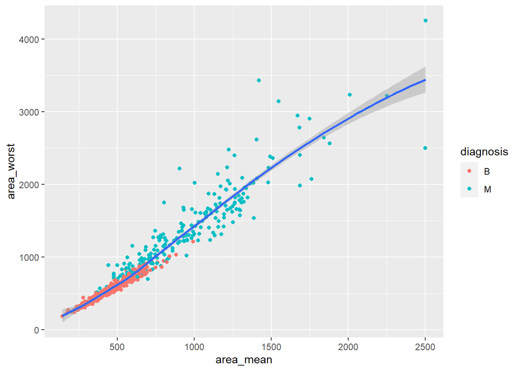

```r
ggplot(data = cancer, mapping = aes(x = area_mean, y = area_worst)) +
  geom_point(mapping = aes(color = diagnosis)) +
  geom_smooth()
```

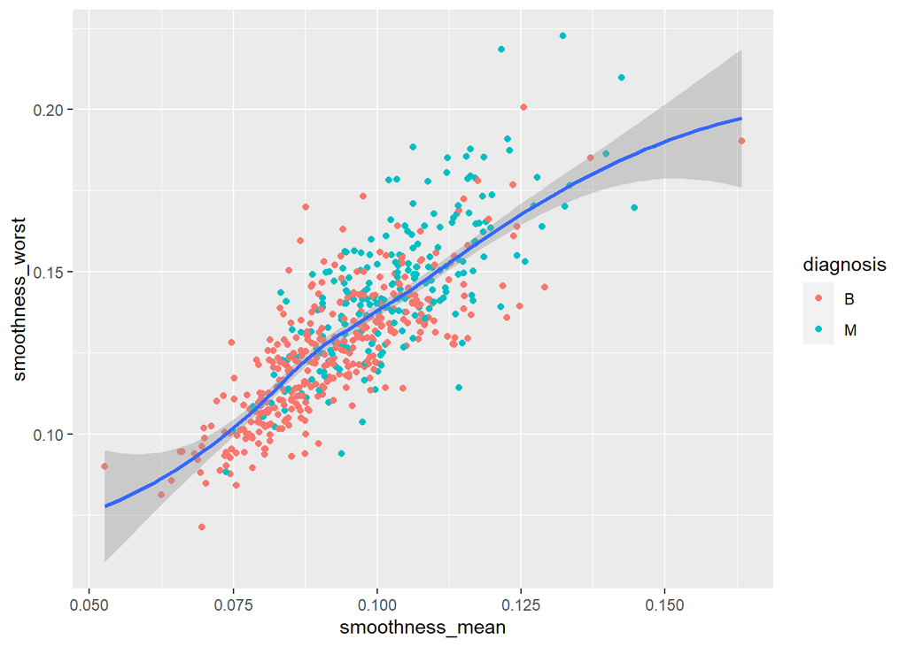

```r
ggplot(data = cancer, mapping = aes(x = smoothness_mean, y = smoothness_worst)) +
  geom_point(mapping = aes(color = diagnosis)) +
  geom_smooth()
```

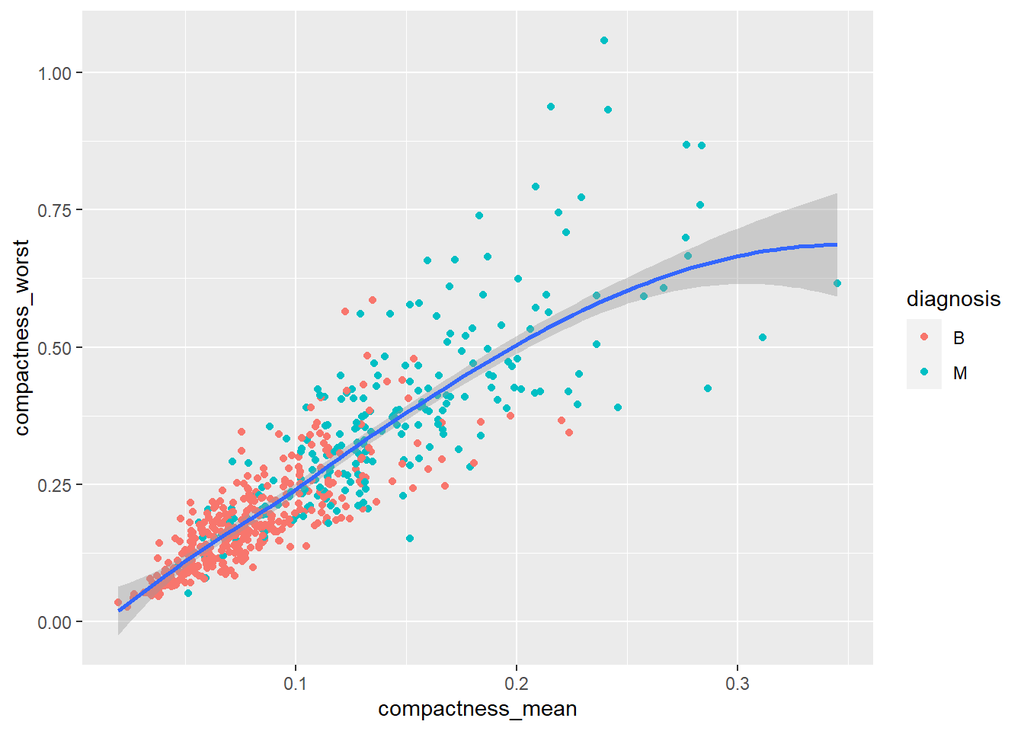

```r
ggplot(data = cancer, mapping = aes(x = compactness_mean, y = compactness_worst)) +
  geom_point(mapping = aes(color = diagnosis)) +
  geom_smooth()
```

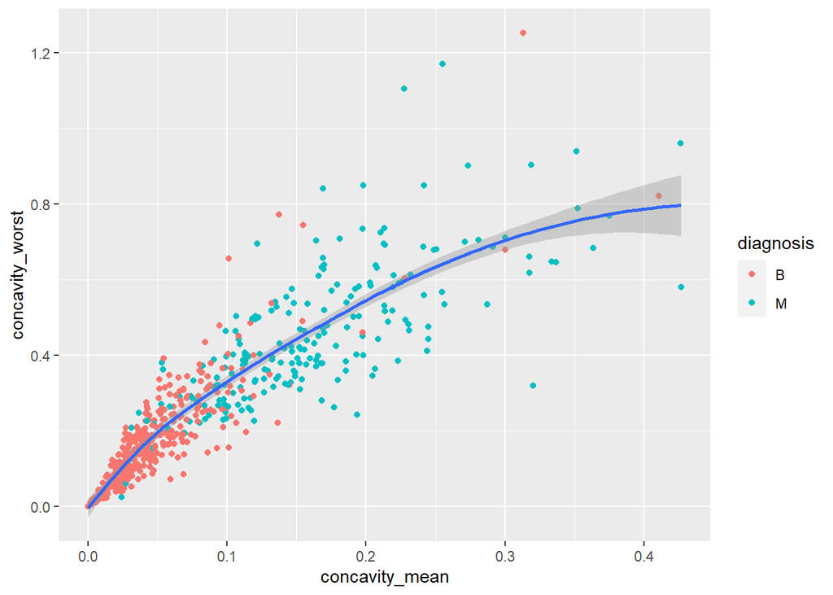

```r
ggplot(data = cancer, mapping = aes(x = concavity_mean, y = concavity_worst)) +
  geom_point(mapping = aes(color = diagnosis)) +
  geom_smooth()
```

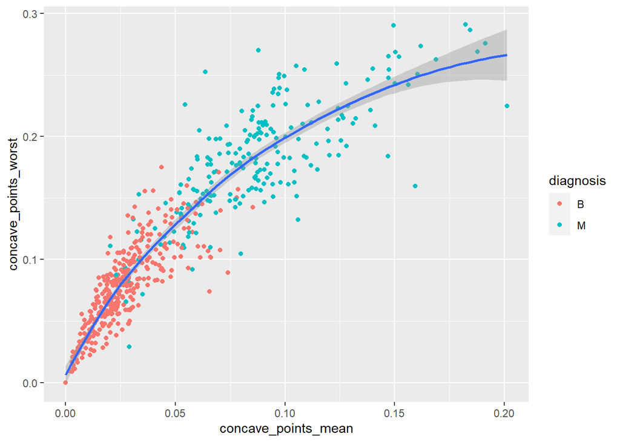

```r
ggplot(data = cancer, mapping = aes(x = concave_points_mean, y = concave_points_worst)) +
  geom_point(mapping = aes(color = diagnosis)) +
  geom_smooth()
```

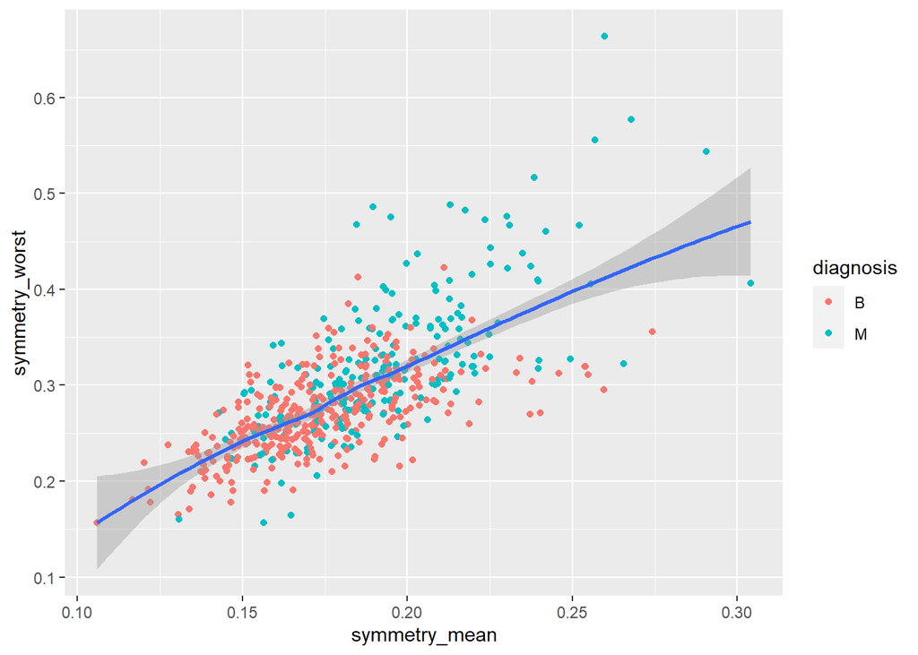

```r
ggplot(data = cancer, mapping = aes(x = symmetry_mean, y = symmetry_worst)) +
  geom_point(mapping = aes(color = diagnosis)) +
  geom_smooth()
```

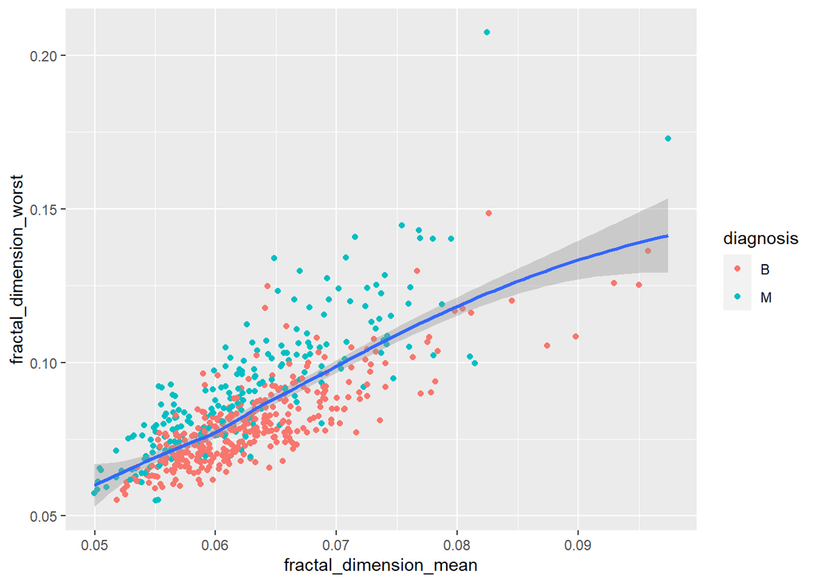

```r
ggplot(data = cancer, mapping = aes(x = fractal_dimension_mean, y = fractal_dimension_worst)) +
  geom_point(mapping = aes(color = diagnosis)) +
  geom_smooth()
```

3. Do the variables concavity_mean and compactness_mean have strong corrolation? What is their relationship?

```r
cancer <- cancer_sample

range_concavity_mean=max(cancer$concavity_mean)-min(cancer$concavity_mean)

mean_concavity_mean=mean(cancer$concavity_mean)

median_concavity_mean=median(cancer$concavity_mean)

sd_concavity_mean=sd(cancer$concavity_mean)

cat("The range of concavity_mean is equal to ", range_concavity_mean, "\n")
```

```
## The range of concavity_mean is equal to  0.4268
```

```r
cat("The mean of concavity_mean is equal to ", mean_concavity_mean, "\n")
```

```
## The mean of concavity_mean is equal to  0.08879932
```

```r
cat("The median of concavity_mean is equal to ", median_concavity_mean, "\n")
```

```
## The median of concavity_mean is equal to  0.06154
```

```r
cat("The standard deviation of concavity_mean is equal to ", sd_concavity_mean, "\n")
```

```
## The standard deviation of concavity_mean is equal to  0.07971981
```

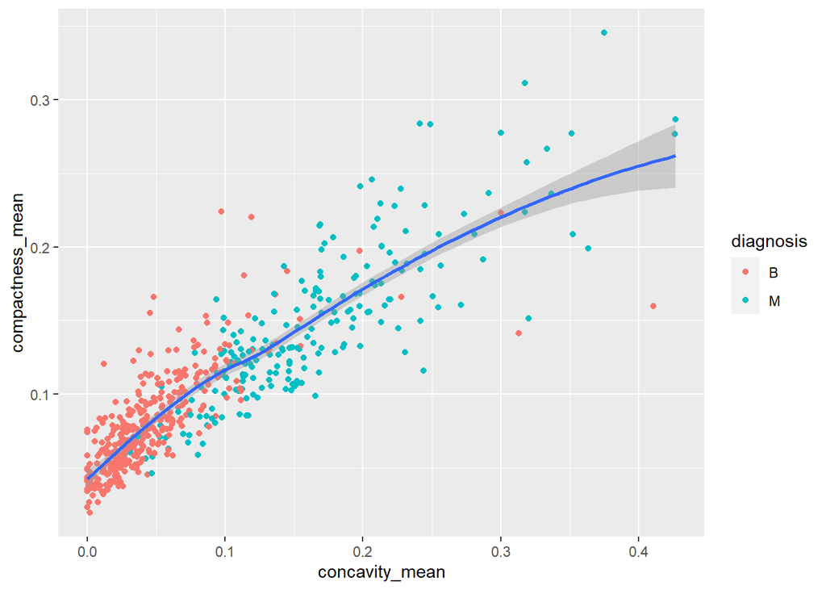

```r
ggplot(data = cancer, mapping = aes(x = concavity_mean, y = compactness_mean)) +
  geom_point(mapping = aes(color = diagnosis)) +
  geom_smooth()
```

4. Based on the graphs, we can predict diagnosis by some variables like radius_mean, area_mean,…. It seems that we only need to use one of the variables radius_mean, area_mean, perimeter_mean. So let’s look at the following graph

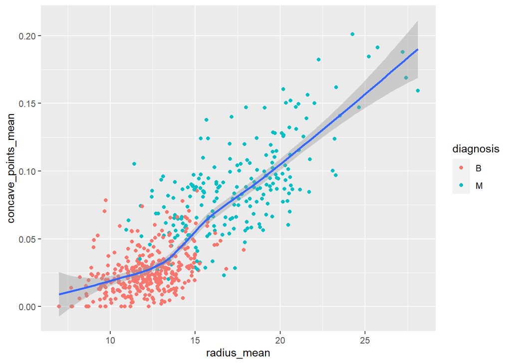

```r
ggplot(data = cancer, mapping = aes(x = radius_mean, y = concave_points_mean)) +
  geom_point(mapping = aes(color = diagnosis)) +
  geom_smooth()
```

It seems we can use the variables radius_mean and concave_points_mean to predict diagnosis.

### 1.3 (2.5 points)

Based on the operations that you’ve completed, how much closer are you to answering your research questions? Think about what aspects of your research questions remain unclear. Can your research questions be refined, now that you’ve investigated your data a bit more? Which research questions are yielding interesting results?

I find out that many variables have strong correlation with each other. So, in order to predict the diagnosis, we only need few variables and can ignore other variables who have strong correlation with them. In particular, few variabels such as radius_mean, concave_points_mean and concavity_mean indicate better the type of diagnosis.

# Task 2: Tidy your data (12.5 points)

In this task, we will do several exercises to reshape our data. The goal here is to understand how to do this reshaping with the `tidyr` package.

A reminder of the definition of *tidy* data:

- Each row is an **observation**
- Each column is a **variable**
- Each cell is a **value**

*Tidy’ing* data is sometimes necessary because it can simplify computation. Other times it can be nice to organize data so that it can be easier to understand when read manually.

### 2.1 (2.5 points)

Based on the definition above, can you identify if your data is tidy or untidy? Go through all your columns, or if you have >8 variables, just pick 8, and explain whether the data is untidy or tidy.

The data is tidy because - Each variable has its own column. - Each observation has its own row. - Each value has its own cell.

### 2.2 (5 points)

Now, if your data is tidy, untidy it! Then, tidy it back to it’s original state.

If your data is untidy, then tidy it! Then, untidy it back to it’s original state.

Be sure to explain your reasoning for this task. Show us the “before” and “after”.

```r
(cancer_sample_untidy <- cancer_sample %>%
    pivot_wider(id_cols = c(-radius_mean),
                names_from = diagnosis,
                values_from = radius_mean)
 )
```

```
## # A tibble: 569 x 32
##        ID texture_mean perimeter_mean area_mean smoothness_mean compactness_mean
##     <dbl>        <dbl>          <dbl>     <dbl>           <dbl>            <dbl>
##  1 8.42e5         10.4          123.      1001           0.118            0.278
##  2 8.43e5         17.8          133.      1326           0.0847           0.0786
##  3 8.43e7         21.2          130       1203           0.110            0.160
##  4 8.43e7         20.4           77.6      386.          0.142            0.284
##  5 8.44e7         14.3          135.      1297           0.100            0.133
##  6 8.44e5         15.7           82.6      477.          0.128            0.17
##  7 8.44e5         20.0          120.      1040           0.0946           0.109
##  8 8.45e7         20.8           90.2      578.          0.119            0.164
##  9 8.45e5         21.8           87.5      520.          0.127            0.193
## 10 8.45e7         24.0           84.0      476.          0.119            0.240
## # ... with 559 more rows, and 26 more variables: concavity_mean <dbl>,
## #   concave_points_mean <dbl>, symmetry_mean <dbl>,
## #   fractal_dimension_mean <dbl>, radius_se <dbl>, texture_se <dbl>,
## #   perimeter_se <dbl>, area_se <dbl>, smoothness_se <dbl>,
## #   compactness_se <dbl>, concavity_se <dbl>, concave_points_se <dbl>,
## #   symmetry_se <dbl>, fractal_dimension_se <dbl>, radius_worst <dbl>,
## #   texture_worst <dbl>, perimeter_worst <dbl>, area_worst <dbl>,
## #   smoothness_worst <dbl>, compactness_worst <dbl>, concavity_worst <dbl>,
## #   concave_points_worst <dbl>, symmetry_worst <dbl>,
## #   fractal_dimension_worst <dbl>, M <dbl>, B <dbl>
```

This dataframe is untidy because there is no value in many cells for columns M and B.

```r
(cancer_sample_tidy <- cancer_sample_untidy %>%
  pivot_longer(cols = c(M,B),
               values_drop_na = TRUE,
               names_to  = "diagnosis",
               values_to = "raduis_mean"))
```

```
## # A tibble: 569 x 32
##        ID texture_mean perimeter_mean area_mean smoothness_mean compactness_mean
##     <dbl>        <dbl>          <dbl>     <dbl>           <dbl>            <dbl>
##  1 8.42e5         10.4          123.      1001           0.118            0.278
##  2 8.43e5         17.8          133.      1326           0.0847           0.0786
##  3 8.43e7         21.2          130       1203           0.110            0.160
##  4 8.43e7         20.4           77.6      386.          0.142            0.284
##  5 8.44e7         14.3          135.      1297           0.100            0.133
##  6 8.44e5         15.7           82.6      477.          0.128            0.17
##  7 8.44e5         20.0          120.      1040           0.0946           0.109
##  8 8.45e7         20.8           90.2      578.          0.119            0.164
##  9 8.45e5         21.8           87.5      520.          0.127            0.193
## 10 8.45e7         24.0           84.0      476.          0.119            0.240
## # ... with 559 more rows, and 26 more variables: concavity_mean <dbl>,
## #   concave_points_mean <dbl>, symmetry_mean <dbl>,
## #   fractal_dimension_mean <dbl>, radius_se <dbl>, texture_se <dbl>,
## #   perimeter_se <dbl>, area_se <dbl>, smoothness_se <dbl>,
## #   compactness_se <dbl>, concavity_se <dbl>, concave_points_se <dbl>,
## #   symmetry_se <dbl>, fractal_dimension_se <dbl>, radius_worst <dbl>,
## #   texture_worst <dbl>, perimeter_worst <dbl>, area_worst <dbl>,
## #   smoothness_worst <dbl>, compactness_worst <dbl>, concavity_worst <dbl>,
## #   concave_points_worst <dbl>, symmetry_worst <dbl>,
## #   fractal_dimension_worst <dbl>, diagnosis <chr>, raduis_mean <dbl>
```

I again put it tidy format using pivot_longer.

### 2.3 (5 points)

Now, you should be more familiar with your data, and also have made progress in answering your research questions. Based on your interest, and your analyses, pick 2 of the 4 research questions to continue your analysis in milestone 3, and explain your decision.

Try to choose a version of your data that you think will be appropriate to answer these 2 questions in milestone 3. Use between 4 and 8 functions that we’ve covered so far (i.e. by filtering, cleaning, tidy’ing, dropping irrelvant columns, etc.). Save this tibble as an `.RDS` object with the function `saveRDS()`.

```r
(cancer_sample_two <- cancer_sample[,c(1:12)]  %>%
   drop_na()%>%
   filter(radius_mean<22)
 )
```

```
## # A tibble: 555 x 12
##        ID diagnosis radius_mean texture_mean perimeter_mean area_mean
##     <dbl> <chr>           <dbl>        <dbl>          <dbl>     <dbl>
##  1 8.42e5 M                18.0         10.4          123.      1001
##  2 8.43e5 M                20.6         17.8          133.      1326
##  3 8.43e7 M                19.7         21.2          130       1203
##  4 8.43e7 M                11.4         20.4           77.6      386.
##  5 8.44e7 M                20.3         14.3          135.      1297
##  6 8.44e5 M                12.4         15.7           82.6      477.
##  7 8.44e5 M                18.2         20.0          120.      1040
##  8 8.45e7 M                13.7         20.8           90.2      578.
##  9 8.45e5 M                13           21.8           87.5      520.
## 10 8.45e7 M                12.5         24.0           84.0      476.
## # ... with 545 more rows, and 6 more variables: smoothness_mean <dbl>,
## #   compactness_mean <dbl>, concavity_mean <dbl>, concave_points_mean <dbl>,
## #   symmetry_mean <dbl>, fractal_dimension_mean <dbl>
```

```r
saveRDS(cancer_sample_two, file = "mydataframe.rds")
```

For now, I only found 3 appropriate functions to apply to this data frame.

*When you are done, knit an `md` file. This is what we will mark! Make sure to open it and check that everything has knitted correctly before submitting your tagged release.*